# Multi-layered forest

[NO_MLFA_001]

Authors

Affiliations

Aud Helen Halbritter

University of Bergen

Ken Olaf Storaunet

Norwegian Institute of Bioeconomy Research

Erik Framstad

Norwegian Institute for Nature Research

Mari Jönsson

Norwegian Institute for Nature Research

Oliver Snoksrud

Norwegian Institute of Bioeconomy Research

Ulrika Jansson Asplund

Norwegian Institute for Nature Research

Published

May 13, 2026

Reviewed by

Matthew Grainger

> **Recommended citation**: Halbritter, A. H., Storaunet, K. O., Framstad, E., Jönsson, M., Snoksrud, O., and Jansson Asplund, U. 2026. Multi-layered forest (ID(s): NO_MLFA_001) v. 000.002. ecRxiv: https://github.com/NINAnor/ecRxiv/tree/main/indicators/NO_MLFA_001

**TipMetadata**

Table 1: Indicator metadata

| Variable | Value |
| --- | --- |
| Indicator ID | NO_MLFA_001 |
| Indicator Name | Multi-layered forest |
| verbatimName | Flersjiktet skog |
| Country | Norway |
| Continent | Europe |
| Ecosystem Condition Typology Class | B2 - Structural State Characteristics |
| Realm | Terrestrial (T) |
| Biome | T2 Temperate-boreal forests and woodlands biome |
| Ecosystem | T2.1 Boreal/montane forests; T2.2 Deciduous temperate forests |
| verbatimEcosystem | T2.1 Boreal/subalpin skot; T2.2 Temperert edellauvskog |
| Year added | 2024 |
| Last update | 2026 |
| Version | 000.002 |
| Version comment | County/sub-county reference scaling (X0 = 0%, X100 varies by unit); scaled regional/national bootstrap |
| Normalised | TRUE |
| Spatial aggregation pathway | Aggregate (NFI plots to county) - [Scale - Truncate] - Aggregate (geographic region) - Aggregate (national level) |
| Precision | Approximate 95% bootstrap interval (2.5th–97.5th percentile of 1000 bootstrap draws) as inferential uncertainty around the point estimate (median). At county or sub-county level, bootstrapping is appl… |

**TipLog**

- 08 Nov. 2025 - Original PR
- 13 May 2026 - ecRxiv template workflow; MLFA denominator includes NA as ensiktet; county/sub-county scaling (X0 = 0%, X100 varies by unit), truncation, split-county units; scaled regional/national bootstrap
- 19 July 2026 - Accepted

## 2. About the underlying data

### 2.1 Spatial and temporal resolution and extent

Data are available from the mid-1990s, when current recording methods were established. Annual estimates are possible due to representative sampling every year. For this indicator all data from each full inventory cycle of 5 years are used, starting in 2010. The data are representative for all productive forest land within the selected region. Spatial resolution should be limited to the resolution allowing for reliable estimates, probably counties.

### 2.2 Sampling design

There are about 12 000 NFI plots in forest ecosystems, distributed on a regular grid, with varying grid density for forest below/above the coniferous forest line and in Finnmark county. All NFI plots are sampled over a 5-year period, with a representative sampling scheme every year, allowing unbiased estimates from data for each year. Stands are classified as single-layered, two-layered, or multi-layered. A single-layered stand consists predominantly of trees in one canopy layer. A two-layered stand consists of two distinct canopy layers representing different stand development stages. The lower layer must contain viable trees to form a stand if the upper layer is removed. A multi-layered stand contains three or more canopy layers, with continuous variation in tree age and size. After removal of the upper canopy, the remaining trees should still constitute a two- or multi-layered stand.

Tree layers are described in the variable `best_form` extracted from the NFI data. It iscategorical and the multi-layered category states that the forest has trees in more than two vertical layers, where tree-age variation also is a characteristic of the stand.

### 2.3 Original units

The indicator is specified as the area-weighted proportion (%) of productive forest area with more than two vertical tree layers (`best_form` = 3), relative to the total productive forest area.

### 2.4 Instructions for citing, using and accessing data

The data used for this indicator have been made available by the Norwegian National Forest Inventory under a specific data use agreement of 2025-10-20, between NIBIO and the specified users. Further use of these data requires a separate data user agreement with NIBIO.

## 3. Indicator properties

### 3.1 Ecosystem Condition Typology Class (ECT)

The multilayered forest indicator represents a structural attribute of the forests. Hence, this indicator represents a B2 Biotic structural characteristic.

### 3.2 Ecosystem condition characteristic

### 3.3 Collinearities with other indicators

There might be a positive correlation with the indicator for large trees. The variable values for multi-layered forest and biologically old forest do not seem to correlate.

### 3.4 Impact factors

Natural disturbances and succession at small scale or with moderate severity will generally result in multi-layered forests. Severe, stand-replacing disturbances may result in one-layered forests, but such disturbances are expected to be rare. Modern even-aged forestry practices will result in one tree layer for much of the managed forest.

## 4. Reference condition and levels

### 4.1 Reference condition

The reference condition is considered to be intact forest ecosystems, where effects of human activities are clearly subordinate to those of natural ecosystem processes and disturbances.

### 4.2 Reference levels

For the analyses below we use county/sub-county-specific reference levels: *X<sub>0</sub>* = 0% (no multi-layered forest) and *X<sub>100</sub>* (area percentage of forest being multilayered expected under reference conditions) varying among county/sub-county units. The lower reference value (*X<sub>0</sub>*) is set to 0%. For lack of better knowledge, the relationship between indicator values and ecosystem condition is assumed to be linear for values between *X<sub>100</sub>* and *X<sub>0</sub>*. County values are scaled to 0–1; values above *X<sub>100</sub>* are truncated to 1. Regional and national scaled point estimates are area-weighted means of scaled county/sub-county values.

#### 4.2.1 Spatial resolution and validity

The reference value will be given as an overall aggregated value for the share of multi-layered productive forest for larger areas such as counties. Although indicator values from NFI plots may technically be aggregated at finer spatial units than counties, scaling indicator values at such finer spatial levels may result in biases.

## 5. Uncertainties

### 5.1 General uncertainties

Uncertainties relate to the variability in the frequency of forest layers among NFI plots and assessment errors for tree layers within NFI plots. This uncertainty is quantified by bootstrapping; the results report the resulting uncertainty for scaled values.

There will also be uncertainty related to the setting of the upper reference value and to the shape of the relationship between indicator values and ecosystem condition. These uncertainties are not quantified.

### 5.2 Reported uncertainties

For non-scaled values, plots are resampled with replacement within each county and the ratio *flersjiktet / (ensjiktet + tosjiktet + flersjiktet + NA)* is recalculated in each replicate. NA mainly represent young forest (age classes I–II). For scaled county values, those bootstrap draws are transformed with the same linear normalisation used for point estimates. For scaled regional and national values, uncertainty is propagated from scaled county bootstrap draws. The scaled tables in section 10 report the median and quantile intervals from these propagated distributions.

## 6. References

Viken, K. O. 2025. *Landsskogtakseringens feltinstruks — 2025*. Vol. 11. 8. NIBIO Bok.

## 7. Import and prepare datasets

### 7.1 Dataset Multi-layered forest

The number of tree layers is recorded for each 0.1 ha area around NFI inventory plots (Viken 2025). There are about 12 000 NFI plots in forest ecosystems, distributed on a regular grid, with varying grid density for forest below/above the coniferous forest line and in Finnmark county. The indicator value is an unbiased area-weighted estimate of the share of the productive forest area with more than two tree layers, for included NFI plots in any selected region. All NFI plots are sampled over a 5-year period, with a representative sampling scheme every year, allowing unbiased estimates from data for each year. For this indicator data from each full inventory cycle of 5 years are used, starting in 2010, meaning that results reported for 2024 are based on data from the years 2020-2024.

**Load data**

```r
lsk_data_file <- here("data/LSK_data_okologisk_tilstand_2026-06-03.csv")

lsk_data_raw <- read_csv(
  lsk_data_file,
  show_col_types = FALSE,
  locale = locale(encoding = "UTF-8")
) |>
  clean_names()
```

## 8. Spatial units

Aggregated indicator values are reported for counties, regions, and nationally. Where counties are split into parts in the NFI export, MLFA uses county/sub-county units matching the reference table in section 9.4. Aggregated indicator values should not be applied for spatial units finer than those that allow reliable estimates, probably counties or sub-counties.

## 9. Analyses

### 9.1 Prepare data and create derived variables

This section prepares the NFI plot data for calculating the indicator.

First we define the 5-year reporting periods that match the temporal structure of the indicator.

```r
# Define multiple 5-year reporting periods starting from 2010
reporting_periods <- list(
  "2010-2014" = 2010:2014,
  "2015-2019" = 2015:2019,
  "2020-2024" = 2020:2024
)
```

Next we filter the raw dataset to include only productive forest plots (`arealtype` = 1), standardise the geography fields, and compute plot-level weights for the MLFA ratio. The indicator is based on the NFI variable `best_form` predominantly, where a value of `"3"` indicates multi-layered forest (more than two tree layers; *flersjiktet*). Missing `best_form` corresponds to age classes 1 and 2 and is treated as single-layer forest (*enskiktet*). Those plots stay in the dataset and count toward the denominator together with plots coded explicitly as *enskiktet* or *tosjiktet* (`best_form` `"1"` or `"2"`). The reported share is *andel flersjiktet divided by (enskiktet + tosjiktet + flersjiktet + NA)*: the total productive forest area represented by multi-layered plots, divided by the total area of all plots that belong to one of those four classes (with NA counted as *enskiktet*). Plots with any other `best_form` code are left out of both the numerator and the denominator. Each plot contributes its sample area `au_areal` (hectares) to those totals.

```r
lsk_data <- lsk_data_raw |>
  dplyr::filter(arealtype == 1) |>
  dplyr::mutate(
    best_form_chr = as.character(best_form),
    best_form_eligible = is.na(best_form) |
      best_form_chr %in% c("1", "2", "3"),
    fylke_name_raw = region_fylke |>
      stringr::str_remove("^\\d+-\\d+\\s+") |>
      stringr::str_remove("^\\d+\\s*") |>
      stringr::str_squish(),
    county_part = assign_mlfa_county_part(fylke_name_raw),
    fylke_name = normalize_county_parts(fylke_name_raw),
    fylke_name_clean = stringi::stri_trans_general(
      stringr::str_squish(
        tolower(stringr::str_replace_all(fylke_name, "[0-9.-]", " "))
      ),
      "Latin-ASCII"
    ),
    region_code = assign_region_code(fylke_name_clean),
    region_name = assign_region_name(region_code),
    indicator_continuous = dplyr::if_else(
      best_form_eligible & best_form_chr %in% "3",
      1,
      0
    ),
    indicator_continuous_weighted = indicator_continuous * au_areal,
    mlfa_num_weighted = dplyr::if_else(
      best_form_eligible,
      as.numeric(best_form_chr %in% "3") * au_areal,
      0
    ),
    mlfa_den_weighted = dplyr::if_else(
      best_form_eligible,
      au_areal,
      0
    )
  )
```

Finally, we retain only the columns required for subsequent aggregation and reporting.

```r
lsk_data <- lsk_data |>
  dplyr::select(
    sesong,
    au_areal,
    arealtype,
    region_code,
    region_name,
    county_part,
    fylke_name,
    fylke_name_clean,
    best_form,
    indicator_continuous,
    indicator_continuous_weighted,
    mlfa_num_weighted,
    mlfa_den_weighted
  )
```

### 9.2 Calculate non-scaled area-weighted indicator values

With the indicator-specific values we can produce area-weighted summaries for each reporting period at county, region, and national scales.

```r
mlfa_results <- purrr::imap(
  reporting_periods,
  ~ calculate_mlfa_period_indicators(lsk_data, .y, .x)
) |>
  purrr::compact()

mlfa_results_county_all_periods <- purrr::map_dfr(mlfa_results, "county")
mlfa_results_region_all_periods <- purrr::map_dfr(mlfa_results, "region")
mlfa_results_national_all_periods <- purrr::map_dfr(mlfa_results, "national")
```

### 9.3 Bootstrap uncertainty estimation for non-scaled indicator values

Uncertainty in non-scaled values is quantified with county-level bootstrap draws. For each county and reporting period, plots are resampled with replacement 1000 times and the non-scaled ratio is recalculated in each replicate. The non-scaled unit is a proportion of productive forest area (0–1), also presented as percent (%).

**Bootstrap draws per county (1000 per county per period)**

```r
county_draws_long <- purrr::imap_dfr(mlfa_results, function(period_result, period_name) {
  county_meta <- period_result$county |>
    dplyr::select(county_part, fylke_name, total_area, region_code)

  purrr::imap_dfr(
    split(period_result$data, period_result$data$county_part),
    function(county_data, county_code) {
      boot <- bootstrap_mlfa_indicator(county_data, n_bootstrap = 1000)
      dplyr::tibble(
        period           = period_name,
        county_part      = county_code,
        sim_id           = seq_along(boot$draws),
        non_scaled_value = boot$draws
      )
    }
  ) |>
    dplyr::left_join(county_meta, by = "county_part")
})
```

The table below (Table 2) shows the direct area-weighted mean share of multi-layered forest per county for the latest period (`2020-2024`), with approximate 95% bootstrap confidence intervals (2.5th–97.5th percentile of 1000 draws).

Table 2: Non-scaled share of multi-layered forest (%) by county for reporting period 2020–2024. Point estimate is the direct area-weighted mean; 95% CI is derived from 1000 bootstrap draws.

| Period | County | Sub-county | Region | Multi-layered forest area (%) | 95% CI | Total area (ha) | Number of plots |
| --- | --- | --- | --- | --- | --- | --- | --- |
| 2020-2024 | Buskerud | BuSØ | Øst | 35.1 | 31 – 39.1 | 500618 | 604 |
| 2020-2024 | Buskerud | BuV | Øst | 41.9 | 32.2 – 51.4 | 97588 | 114 |
| 2020-2024 | Hedmark | HeN | Øst | 33.5 | 28.9 – 37.7 | 507642 | 555 |
| 2020-2024 | Hedmark | HeS | Øst | 22.8 | 20.2 – 25.3 | 927364 | 1119 |
| 2020-2024 | Oppland | OpNV | Øst | 53.5 | 47.6 – 59.4 | 328359 | 340 |
| 2020-2024 | Oppland | OpSØ | Øst | 31.3 | 27.5 – 35.1 | 508909 | 609 |
| 2020-2024 | Oslo og Akershus | OA | Øst | 29.1 | 24.8 – 33.7 | 331115 | 411 |
| 2020-2024 | Vestfold | Ve | Øst | 38.4 | 30.5 – 46.4 | 133203 | 166 |
| 2020-2024 | Østfold | Øs | Øst | 22.6 | 17.9 – 27.2 | 247119 | 301 |
| 2020-2024 | Agder | AA | Sør | 34.0 | 29.5 – 38.8 | 344523 | 409 |
| 2020-2024 | Agder | VA | Sør | 20.6 | 16 – 25.5 | 308318 | 348 |
| 2020-2024 | Telemark | TeNV | Sør | 44.6 | 39.2 – 50.3 | 270932 | 314 |
| 2020-2024 | Telemark | TeSØ | Sør | 37.5 | 32.7 – 43 | 309575 | 371 |
| 2020-2024 | Hordaland | Ho | Vest | 18.3 | 14.3 – 22.4 | 286504 | 347 |
| 2020-2024 | Rogaland | Ro | Vest | 17.6 | 12.4 – 23.3 | 179069 | 194 |
| 2020-2024 | Sogn og Fjordane | SF | Vest | 31.4 | 26 – 37 | 289485 | 337 |
| 2020-2024 | Møre og Romsdal | MR | Midt | 31.7 | 26.6 – 36.5 | 333087 | 391 |
| 2020-2024 | Trøndelag | NT | Midt | 24.3 | 21.3 – 27.3 | 652837 | 806 |
| 2020-2024 | Trøndelag | ST | Midt | 29.8 | 25.5 – 34 | 469441 | 545 |
| 2020-2024 | Finnmark | Fi | Nord | 45.5 | 33.3 – 58.6 | 396313 | 126 |
| 2020-2024 | Nordland | NoN | Nord | 26.3 | 22.2 – 30.2 | 400359 | 446 |
| 2020-2024 | Nordland | NoS | Nord | 23.5 | 18.8 – 28.2 | 308758 | 360 |
| 2020-2024 | Troms | Tr | Nord | 30.1 | 26 – 34.6 | 470555 | 532 |

### 9.4 Scale indicator values and aggregate to regional and national levels

County or sub-county reference values are created manually andlisted below.

**County/sub-county reference values for MLFA scaling**

```r
mlfa_reference_values <- dplyr::tibble(
  county_part = c(
    "Øs", "OA", "HeS", "HeN", "OpSØ", "OpNV", "BuSØ", "BuV", "Ve",
    "TeSØ", "TeNV", "AA", "VA", "Ro", "Ho", "SF", "MR", "ST", "NT",
    "NoS", "NoN", "Tr", "Fi"
  ),
  x100_pct = c(
    70, 70, 70, 60, 65, 55, 70, 55, 70, 70, 65, 65, 65, 60, 60,
    55, 60, 60, 65, 55, 45, 45, 40
  )
) |>
  mutate(x100=x100_pct/100)

x0 <- 0

mlfa_reference_values |>
  knitr::kable()
```

| county_part | x100_pct | x100 |
| --- | --- | --- |
| Øs | 70 | 0.70 |
| OA | 70 | 0.70 |
| HeS | 70 | 0.70 |
| HeN | 60 | 0.60 |
| OpSØ | 65 | 0.65 |
| OpNV | 55 | 0.55 |
| BuSØ | 70 | 0.70 |
| BuV | 55 | 0.55 |
| Ve | 70 | 0.70 |
| TeSØ | 70 | 0.70 |
| TeNV | 65 | 0.65 |
| AA | 65 | 0.65 |
| VA | 65 | 0.65 |
| Ro | 60 | 0.60 |
| Ho | 60 | 0.60 |
| SF | 55 | 0.55 |
| MR | 60 | 0.60 |
| ST | 60 | 0.60 |
| NT | 65 | 0.65 |
| NoS | 55 | 0.55 |
| NoN | 45 | 0.45 |
| Tr | 45 | 0.45 |
| Fi | 40 | 0.40 |

Each county’s 1000 non-scaled draws from section 9.3 are scaled with `ecTools::ec_normalise()` (linear, *X<sub>0</sub>* = 0, county-specific *X<sub>100</sub>*). Figure 1 shows the mapping for each sub-county.

**Scale county draws; derive county uncertainty and feed ec_upscale**

```r
county_draws_scaled <- county_draws_long |>
  dplyr::inner_join(mlfa_reference_values |> dplyr::select(county_part, x100), by = "county_part") |>
  dplyr::mutate(
    scaled_value = ec_normalise(
      non_scaled_value,
      x0 = x0,
      x100 = x100,
      fun = "linear"
    ),
    nation = "National"
  )

county_scaled_with_uncertainty <- county_draws_scaled |>
  dplyr::group_by(period, fylke_name, county_part, total_area, region_code) |>
  dplyr::summarise(
    median = median(scaled_value, na.rm = TRUE),
    p_025  = as.numeric(quantile(scaled_value, 0.025, na.rm = TRUE)),
    p_25   = as.numeric(quantile(scaled_value, 0.25, na.rm = TRUE)),
    p_75   = as.numeric(quantile(scaled_value, 0.75, na.rm = TRUE)),
    p_975  = as.numeric(quantile(scaled_value, 0.975, na.rm = TRUE)),
    .groups = "drop"
  ) |>
  dplyr::left_join(
    mlfa_results_county_all_periods |> dplyr::select(period, county_part, n_plots),
    by = c("period", "county_part")
  ) |>
  dplyr::mutate(region_name = assign_region_name(region_code))
```

**Normalisation diagnostic figure**

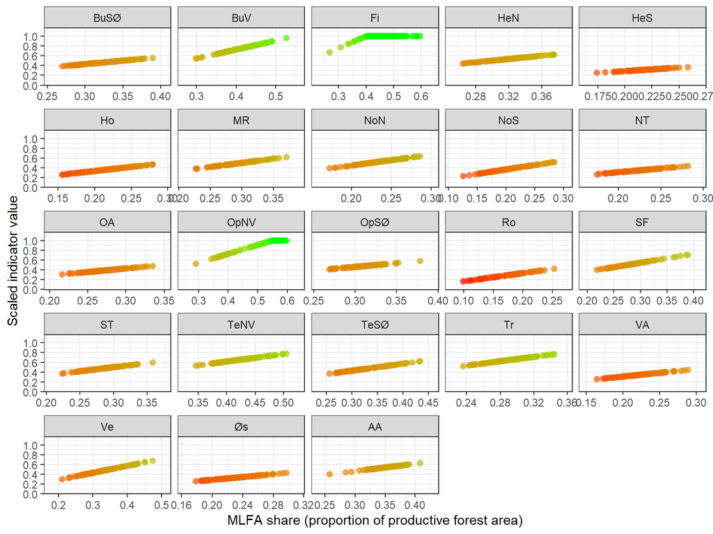

Figure 1: Linear normalisation of the share of multi-layered forest to indicator values (0–1). Each panel shows one sub-county accounting unit, with its own *X<sub>100</sub>* reference value (upper right corner of the scaling line). The x-axis is free-scaled per panel to reflect the range of resampled non-scaled indicator values in that sub-county. Points are a random sample of 100 bootstrap draws (out of 1000) pooled across all reporting periods, illustrating the spread of resampled area-weighted means around the direct estimate. The diagonal line shows the linear scaling function between *X<sub>0</sub>* = 0% (lower reference, worst condition) and the sub-county-specific *X<sub>100</sub>* (upper reference, reference condition); values above *X<sub>100</sub>* are truncated to 1.

```r
norm_plot_data <- county_draws_scaled |>
  dplyr::group_by(county_part) |>
  dplyr::slice_sample(n = 100) |>
  dplyr::ungroup()

mlfa_norm_plot <- ec_norm_plot(norm_plot_data$non_scaled_value, norm_plot_data$scaled_value) +
  ggplot2::facet_wrap(~norm_plot_data$county_part, scales = "free_x") +
  ggplot2::labs(
    x = "MLFA share (proportion of productive forest area)",
    y = "Scaled indicator value"
  ) +
  ggplot2::theme_bw(base_size = 11)
mlfa_norm_plot$layers[[1]]$aes_params$size <- 2.5

suppressMessages(
  ggsave(
    filename = here::here("img/mlfa_norm_plot.png"),
    plot = mlfa_norm_plot,
    scale = 1.5
  )
)

mlfa_norm_plot
```

The scaled draws are then passed to `ecTools::ec_upscale()`, which propagates uncertainty through the spatial hierarchy. For each of 1000 Monte Carlo iterations, one draw is sampled per county and the area-weighted mean gives one regional value; a second `ec_upscale()` call repeats this from regions to national level.

**ec_upscale county to region (compute once, save RDS)**

```r
mlfa_mc_cache_deps <- c(
  here::here("data/LSK_data_okologisk_tilstand_2026-06-03.csv"),
  here::here("R/functions.R"),
  here::here("R/NO_MLFA_001.qmd")
)
mlfa_mc_rds_regional <- here::here("data/mlfa_mc_regional.rds")

if (
  file.exists(mlfa_mc_rds_regional) &&
  file.mtime(mlfa_mc_rds_regional) >= max(file.mtime(mlfa_mc_cache_deps), na.rm = TRUE)
) {
  mlfa_mc_regional <- readRDS(mlfa_mc_rds_regional)
} else {
  mlfa_mc_regional <- ecTools::ec_upscale(
    data        = county_draws_scaled,
    variable    = scaled_value,
    weight      = total_area,
    start_units = county_part,
    end_units   = region_code,
    year        = period,
    end_units_name = "region_code",
    n = 1000
  )
  saveRDS(mlfa_mc_regional, mlfa_mc_rds_regional)
}
```

**ec_upscale region to national (compute once, save RDS)**

```r
region_area_weights <- county_draws_scaled |>
  dplyr::distinct(period, county_part, total_area, region_code) |>
  dplyr::group_by(period, region_code) |>
  dplyr::summarise(region_area = sum(total_area), .groups = "drop")

mlfa_mc_regional_for_national <- mlfa_mc_regional |>
  dplyr::left_join(region_area_weights, by = c("period", "region_code")) |>
  dplyr::mutate(nation = "National")

mlfa_mc_rds_national <- here::here("data/mlfa_mc_national.rds")

if (
  file.exists(mlfa_mc_rds_national) &&
  file.mtime(mlfa_mc_rds_national) >= max(
    c(file.mtime(mlfa_mc_cache_deps), file.mtime(mlfa_mc_rds_regional)),
    na.rm = TRUE
  )
) {
  mlfa_mc_national <- readRDS(mlfa_mc_rds_national)
} else {
  mlfa_mc_national <- ecTools::ec_upscale(
    data        = mlfa_mc_regional_for_national,
    variable    = sampled_mean,
    weight      = region_area,
    start_units = region_code,
    end_units   = nation,
    year        = period,
    end_units_name = "nation",
    n = 1000
  )
  saveRDS(mlfa_mc_national, mlfa_mc_rds_national)
}
```

**Combine regional/national MC draws and build summary objects**

```r
mlfa_mc_combined <- dplyr::bind_rows(
  mlfa_mc_regional |> dplyr::select(period, region = region_code, sampled_mean),
  mlfa_mc_national |> dplyr::select(period, region = nation, sampled_mean)
)

county_scaled_all_periods <- mlfa_results_county_all_periods |>
  dplyr::left_join(mlfa_reference_values |> dplyr::select(county_part, x100), by = "county_part") |>
  dplyr::mutate(
    scaled_value = ec_normalise(indicator_value, x0 = x0, x100 = x100, fun = "linear")
  )

region_scaled_agg_all_periods <- mlfa_mc_regional |>
  dplyr::group_by(period, region_code) |>
  dplyr::summarise(scaled_value = median(sampled_mean), .groups = "drop") |>
  dplyr::mutate(region_name = assign_region_name(region_code))

national_scaled_agg_all_periods <- mlfa_mc_national |>
  dplyr::group_by(period) |>
  dplyr::summarise(scaled_value = median(sampled_mean), .groups = "drop") |>
  dplyr::mutate(region = "National")

region_scaled_agg_with_uncertainty <- mlfa_mc_regional |>
  dplyr::group_by(period, region_code) |>
  dplyr::summarise(
    median = median(sampled_mean),
    p_025  = as.numeric(quantile(sampled_mean, 0.025)),
    p_25   = as.numeric(quantile(sampled_mean, 0.25)),
    p_75   = as.numeric(quantile(sampled_mean, 0.75)),
    p_975  = as.numeric(quantile(sampled_mean, 0.975)),
    .groups = "drop"
  ) |>
  dplyr::mutate(region_name = assign_region_name(region_code)) |>
  dplyr::left_join(
    mlfa_results_region_all_periods |> dplyr::select(period, region_code, total_area, n_plots),
    by = c("period", "region_code")
  )

national_scaled_agg_with_uncertainty <- mlfa_mc_national |>
  dplyr::group_by(period) |>
  dplyr::summarise(
    median = median(sampled_mean),
    p_025  = as.numeric(quantile(sampled_mean, 0.025)),
    p_25   = as.numeric(quantile(sampled_mean, 0.25)),
    p_75   = as.numeric(quantile(sampled_mean, 0.75)),
    p_975  = as.numeric(quantile(sampled_mean, 0.975)),
    .groups = "drop"
  ) |>
  dplyr::mutate(region = "National") |>
  dplyr::left_join(
    mlfa_results_national_all_periods |> dplyr::select(period, total_area, n_plots),
    by = "period"
  )

truncation_summary <- dplyr::bind_rows(
  county_scaled_all_periods |>
    dplyr::left_join(
      mlfa_reference_values |> dplyr::select(county_part, reference_value_pct = x100_pct),
      by = "county_part"
    ) |>
    dplyr::mutate(
      level = "County",
      exceeds_threshold = indicator_value > x100,
      original_value_pct = round(100 * indicator_value, 2),
      region_code = NA_character_,
      region_name = NA_character_
    ) |>
    dplyr::select(
      period, level, region_code, region_name, fylke_name,
      reference_value_pct, exceeds_threshold, original_value_pct
    ),
  region_scaled_agg_all_periods |>
    dplyr::left_join(
      mlfa_results_region_all_periods |> dplyr::select(period, region_code, indicator_value),
      by = c("period", "region_code")
    ) |>
    dplyr::mutate(
      level = "Region",
      reference_value_pct = NA_real_,
      exceeds_threshold = scaled_value >= 1,
      original_value_pct = round(100 * indicator_value, 2),
      fylke_name = NA_character_
    ) |>
    dplyr::select(
      period, level, region_code, region_name, fylke_name,
      reference_value_pct, exceeds_threshold, original_value_pct
    ),
  national_scaled_agg_all_periods |>
    dplyr::left_join(
      mlfa_results_national_all_periods |> dplyr::select(period, indicator_value),
      by = "period"
    ) |>
    dplyr::mutate(
      level = "National",
      reference_value_pct = NA_real_,
      exceeds_threshold = scaled_value >= 1,
      original_value_pct = round(100 * indicator_value, 2),
      region_code = NA_character_,
      region_name = "National",
      fylke_name = NA_character_
    ) |>
    dplyr::select(
      period, level, region_code, region_name, fylke_name,
      reference_value_pct, exceeds_threshold, original_value_pct
    )
)

truncation_counts <- truncation_summary |>
  dplyr::group_by(period, level) |>
  dplyr::summarise(
    n_total = dplyr::n(),
    n_exceeding_reference = sum(exceeds_threshold, na.rm = TRUE),
    pct_exceeding_reference = round(100 * n_exceeding_reference / n_total, 1),
    .groups = "drop"
  )

truncated_values <- truncation_summary |>
  dplyr::filter(exceeds_threshold) |>
  dplyr::arrange(period, level, dplyr::desc(original_value_pct))
```

At county or sub-county level, truncation is evaluated by comparing the non-scaled point estimate to the matching X100. At regional and national level, the tables report cases where the `ec_upscale()` median equals 1. The following tables summarise how often truncation occurred in each period and list the affected units.

| Period | Level | Total | Exceeding reference | % Exceeding reference |
| --- | --- | --- | --- | --- |
| 2010-2014 | County | 23 | 1 | 4.3 |
| 2010-2014 | National | 1 | 0 | 0.0 |
| 2010-2014 | Region | 5 | 0 | 0.0 |
| 2015-2019 | County | 23 | 1 | 4.3 |
| 2015-2019 | National | 1 | 0 | 0.0 |
| 2015-2019 | Region | 5 | 0 | 0.0 |
| 2020-2024 | County | 23 | 1 | 4.3 |
| 2020-2024 | National | 1 | 0 | 0.0 |
| 2020-2024 | Region | 5 | 0 | 0.0 |

| Period | Level | Location | Reference (%) | Original Value (%) |
| --- | --- | --- | --- | --- |
| 2010-2014 | County | Finnmark | 40 | 44.01 |
| 2015-2019 | County | Finnmark | 40 | 45.85 |
| 2020-2024 | County | Finnmark | 40 | 45.54 |

The time series below (Figure 2) summarises regional and national values over the three reporting periods.

**Time series of indicator values by region and period**

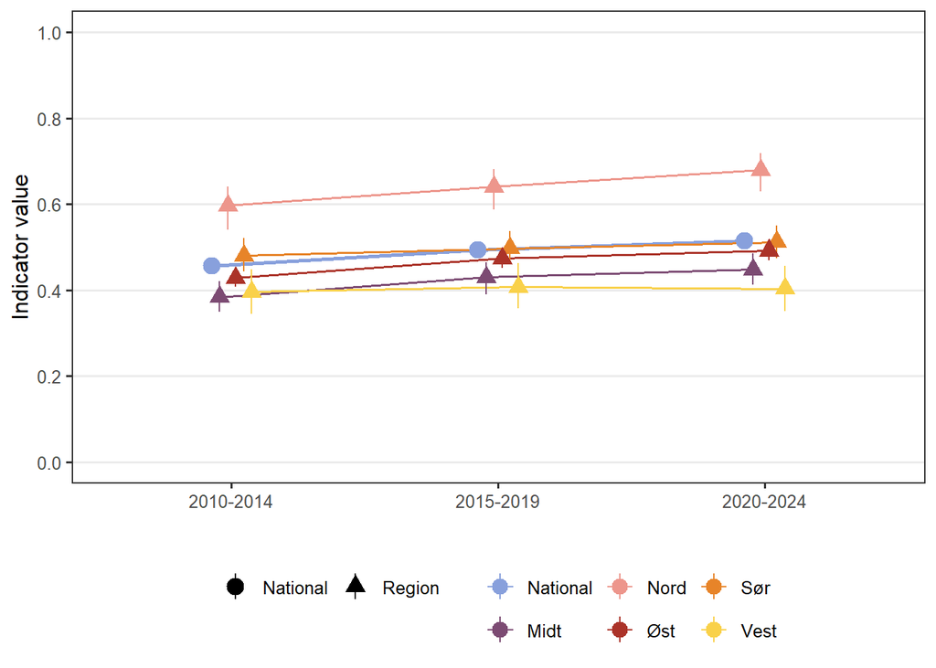

Figure 2: Indicator values for multi-layered forest share by region and reporting period. Points show MC medians; error bars show 95% intervals from Monte Carlo propagation. National values use filled circles and a thicker line.

```r
mlfa_region_labels <- c(
  "1" = "Øst", "2" = "Sør", "3" = "Vest",
  "4" = "Midt", "5" = "Nord", "National" = "National"
)
mlfa_region_levels <- c("National", "Midt", "Nord", "Øst", "Sør", "Vest")
mlfa_region_cols <- setNames(
  MetBrewer::met.brewer("Archambault", n = length(mlfa_region_levels)),
  mlfa_region_levels
)

mlfa_plot_data <- mlfa_mc_combined |>
  dplyr::mutate(
    region_name = dplyr::recode(region, !!!mlfa_region_labels),
    series_type = dplyr::if_else(region == "National", "National", "Region")
  ) |>
  dplyr::group_by(period, region_name, series_type) |>
  dplyr::summarise(
    median = median(sampled_mean),
    p_025  = as.numeric(quantile(sampled_mean, 0.025)),
    p_975  = as.numeric(quantile(sampled_mean, 0.975)),
    .groups = "drop"
  ) |>
  dplyr::mutate(region_name = factor(region_name, levels = mlfa_region_levels))

ggplot2::ggplot(
  mlfa_plot_data,
  ggplot2::aes(x = period, y = median, colour = region_name, group = region_name)
) +
  ggplot2::geom_line(
    ggplot2::aes(linewidth = series_type),
    position = ggplot2::position_dodge(width = 0.18)
  ) +
  ggplot2::geom_pointrange(
    ggplot2::aes(ymin = p_025, ymax = p_975, shape = series_type),
    size = 0.8, linewidth = 0.45,
    position = ggplot2::position_dodge(width = 0.18)
  ) +
  ggplot2::scale_colour_manual(values = mlfa_region_cols, name = NULL) +
  ggplot2::scale_shape_manual(values = c(National = 19, Region = 17), name = NULL) +
  ggplot2::scale_linewidth_manual(values = c(National = 1, Region = 0.55), guide = "none") +
  ggplot2::scale_y_continuous(limits = c(0, 1), breaks = seq(0, 1, 0.2)) +
  ggplot2::theme_bw(base_size = 12) +
  ggplot2::theme(
    legend.position = "bottom",
    legend.box = "horizontal",
    panel.grid.minor = ggplot2::element_blank(),
    panel.grid.major.x = ggplot2::element_blank()
  ) +
  ggplot2::guides(
    colour = ggplot2::guide_legend(nrow = 2, override.aes = list(size = 0.7, linewidth = 0.45)),
    shape = ggplot2::guide_legend(override.aes = list(size = 0.8, linewidth = 0.45))
  ) +
  ggplot2::labs(y = "Indicator value", x = "")
```

## 10. Results

The tables below report scaled values on a 0–1 condition scale. The indicator value is reported as the median, together with a 95% interval (2.5% and 97.5% quantiles) and a 50% interval (25% and 75% quantiles). County medians come from scaled bootstrap draws (section 9.3); regional and national medians come from `ec_upscale()` Monte Carlo draws saved in `data/mlfa_mc_*.rds` (recomputed when the data file, `R/functions.R`, or this document is newer than the RDS).

### 10.1 County-level results (scaled with uncertainty)

Use the search box and page controls in Table 3 to browse county rows across all reporting periods.

Table 3: County-level MLFA values by reporting period (0–1 condition scale; `ec_normalise()` with *X<sub>0</sub>* = 0 and county/sub-county-specific *X<sub>100</sub>*). The indicator value is the median of scaled county bootstrap draws (section 9.3–9.4); 95% and 50% CI columns are quantile intervals from the same distribution.

| ECT | Indicator | ID | Accounting area | Region | Sub-county | Ecosystem | Reporting period | Indicator value | 95% CI | 50% CI | Number of plots |
| --- | --- | --- | --- | --- | --- | --- | --- | --- | --- | --- | --- |
| B2 | Multi-layered forest share | NO_MLFA_001 | Buskerud | Øst | BuSØ | Boreal/montane forests | 2010-2014 | 0.42 | 0.36 - 0.47 | 0.4 - 0.43 | 603 |
| B2 | Multi-layered forest share | NO_MLFA_001 | Buskerud | Øst | BuV | Boreal/montane forests | 2010-2014 | 0.73 | 0.55 - 0.91 | 0.67 - 0.79 | 114 |
| B2 | Multi-layered forest share | NO_MLFA_001 | Hedmark | Øst | HeN | Boreal/montane forests | 2010-2014 | 0.51 | 0.44 - 0.59 | 0.49 - 0.54 | 552 |
| B2 | Multi-layered forest share | NO_MLFA_001 | Hedmark | Øst | HeS | Boreal/montane forests | 2010-2014 | 0.3 | 0.26 - 0.33 | 0.28 - 0.31 | 1114 |
| B2 | Multi-layered forest share | NO_MLFA_001 | Oppland | Øst | OpNV | Boreal/montane forests | 2010-2014 | 0.69 | 0.58 - 0.8 | 0.66 - 0.73 | 334 |
| B2 | Multi-layered forest share | NO_MLFA_001 | Oppland | Øst | OpSØ | Boreal/montane forests | 2010-2014 | 0.46 | 0.4 - 0.51 | 0.44 - 0.48 | 612 |
| B2 | Multi-layered forest share | NO_MLFA_001 | Oslo og Akershus | Øst | OA | Boreal/montane forests | 2010-2014 | 0.38 | 0.31 - 0.44 | 0.35 - 0.4 | 407 |
| B2 | Multi-layered forest share | NO_MLFA_001 | Vestfold | Øst | Ve | Boreal/montane forests | 2010-2014 | 0.41 | 0.32 - 0.52 | 0.38 - 0.45 | 161 |
| B2 | Multi-layered forest share | NO_MLFA_001 | Østfold | Øst | Øs | Boreal/montane forests | 2010-2014 | 0.35 | 0.28 - 0.42 | 0.32 - 0.37 | 295 |
| B2 | Multi-layered forest share | NO_MLFA_001 | Agder | Sør | AA | Boreal/montane forests | 2010-2014 | 0.52 | 0.45 - 0.6 | 0.5 - 0.55 | 399 |

[output cut: 59 more lines]

### 10.2 Regional results (scaled with uncertainty)

Table 4: Regional scaled MLFA values by reporting period (0–1 condition scale). The indicator value is the median of Monte Carlo draws (1000 samples per period and region); 95% and 50% CI columns are quantile intervals from the same distribution.

| ECT | Indicator | ID | Accounting area | Ecosystem | Reporting period | Indicator value | 95% CI | 50% CI | Number of plots |
| --- | --- | --- | --- | --- | --- | --- | --- | --- | --- |
| B2 | Multi-layered forest share | NO_MLFA_001 | Øst | Boreal/montane forests | 2010-2014 | 0.43 | 0.41 - 0.45 | 0.42 - 0.44 | 4192 |
| B2 | Multi-layered forest share | NO_MLFA_001 | Sør | Boreal/montane forests | 2010-2014 | 0.48 | 0.44 - 0.52 | 0.47 - 0.49 | 1426 |
| B2 | Multi-layered forest share | NO_MLFA_001 | Vest | Boreal/montane forests | 2010-2014 | 0.40 | 0.34 - 0.45 | 0.38 - 0.41 | 857 |
| B2 | Multi-layered forest share | NO_MLFA_001 | Midt | Boreal/montane forests | 2010-2014 | 0.38 | 0.35 - 0.42 | 0.37 - 0.4 | 1735 |
| B2 | Multi-layered forest share | NO_MLFA_001 | Nord | Boreal/montane forests | 2010-2014 | 0.60 | 0.54 - 0.64 | 0.58 - 0.61 | 1425 |
| B2 | Multi-layered forest share | NO_MLFA_001 | Øst | Boreal/montane forests | 2015-2019 | 0.47 | 0.45 - 0.5 | 0.47 - 0.48 | 4189 |
| B2 | Multi-layered forest share | NO_MLFA_001 | Sør | Boreal/montane forests | 2015-2019 | 0.50 | 0.46 - 0.54 | 0.48 - 0.51 | 1433 |
| B2 | Multi-layered forest share | NO_MLFA_001 | Vest | Boreal/montane forests | 2015-2019 | 0.41 | 0.36 - 0.46 | 0.39 - 0.42 | 864 |
| B2 | Multi-layered forest share | NO_MLFA_001 | Midt | Boreal/montane forests | 2015-2019 | 0.43 | 0.39 - 0.46 | 0.42 - 0.44 | 1744 |
| B2 | Multi-layered forest share | NO_MLFA_001 | Nord | Boreal/montane forests | 2015-2019 | 0.64 | 0.59 - 0.68 | 0.63 - 0.65 | 1461 |
| B2 | Multi-layered forest share | NO_MLFA_001 | Øst | Boreal/montane forests | 2020-2024 | 0.49 | 0.47 - 0.51 | 0.48 - 0.5 | 4219 |
| B2 | Multi-layered forest share | NO_MLFA_001 | Sør | Boreal/montane forests | 2020-2024 | 0.51 | 0.47 - 0.55 | 0.5 - 0.52 | 1442 |
| B2 | Multi-layered forest share | NO_MLFA_001 | Vest | Boreal/montane forests | 2020-2024 | 0.40 | 0.35 - 0.46 | 0.39 - 0.42 | 878 |
| B2 | Multi-layered forest share | NO_MLFA_001 | Midt | Boreal/montane forests | 2020-2024 | 0.45 | 0.41 - 0.49 | 0.44 - 0.46 | 1742 |
| B2 | Multi-layered forest share | NO_MLFA_001 | Nord | Boreal/montane forests | 2020-2024 | 0.68 | 0.63 - 0.72 | 0.66 - 0.69 | 1464 |

### 10.3 National results (scaled with uncertainty)

Table 5: National scaled MLFA values by reporting period (0–1 condition scale). The indicator value is the median of Monte Carlo draws (1000 samples per period); 95% and 50% CI columns are quantile intervals from the same distribution.

| ECT | Indicator | ID | Accounting area | Ecosystem | Reporting period | Indicator value | 95% CI | 50% CI | Number of plots |
| --- | --- | --- | --- | --- | --- | --- | --- | --- | --- |
| B2 | Multi-layered forest share | NO_MLFA_001 | National | Boreal/montane forests | 2010-2014 | 0.46 | 0.44 - 0.47 | 0.45 - 0.46 | 9635 |
| B2 | Multi-layered forest share | NO_MLFA_001 | National | Boreal/montane forests | 2015-2019 | 0.49 | 0.48 - 0.51 | 0.49 - 0.5 | 9691 |
| B2 | Multi-layered forest share | NO_MLFA_001 | National | Boreal/montane forests | 2020-2024 | 0.51 | 0.5 - 0.53 | 0.51 - 0.52 | 9745 |

## 11. Export file

**Export regional and national MC-propagated indicator draws**

```r
write.csv(
  mlfa_mc_combined,
  here::here("data/results_NO_MLFA_001.csv"),
  row.names = FALSE
)
```

## 12. Author contributions

**CRediT statement**

- Conceptualization: [KOS, EF, UJA]
- Methodology: [KOS, EF, UJA]
- Data curation: [OS]
- Formal analysis: [AHH]
- Validation: [AHH, KOS]
- Visualization: [AHH]
- Writing – original draft: [AHH, EF]
- Writing – review & editing: [All]

**MeRIT attribution**

This part supplements the CRediT statement with more granularity for method section.

**TipSession Info**

This workflow uses `renv`. Run `renv::restore()` to recreate the working environment.